# DATA ANALYSIS USING R

Himank Jain

February 8, 2019

#Contents

This is an R Markdown document consisting basic methods oF *data analysis, stastical inFerence, data visualization* and some other inbuilt Function oF R. A large part oF the data and methods used in this document were taken From Foundation OF Data Analysis part-I From **edx** https://courses.edx.org/courses/course-v1:UTAustinX+UT.7.11x+2T2017/course/

#UniVariate Data: Univariate means “one variable” (one type oF data) Example: You weigh the pups and get these results: 1,3,4,6,8,10,12 The one variable is Puppy Weight

```r
pups=c(1,3,3,3,3,4,6,6,6,7,8,10,10)
```

##Measure OF Center In Univariate Data * Mean:The arithmetic mean is the central value oF a discrete set oF numbers: speciFically, the sum oF the values divided by the number oF values.
$$\frac{\sum X}{n}$$

For our puppy weights data set mean is:

```r
mean(pups)
```

```
## [1] 5.384615
```

*Median:The median is the value separating the higher halF From the lower halF oF a data sample. For a data set, it may be thought oF as the “middle” value.

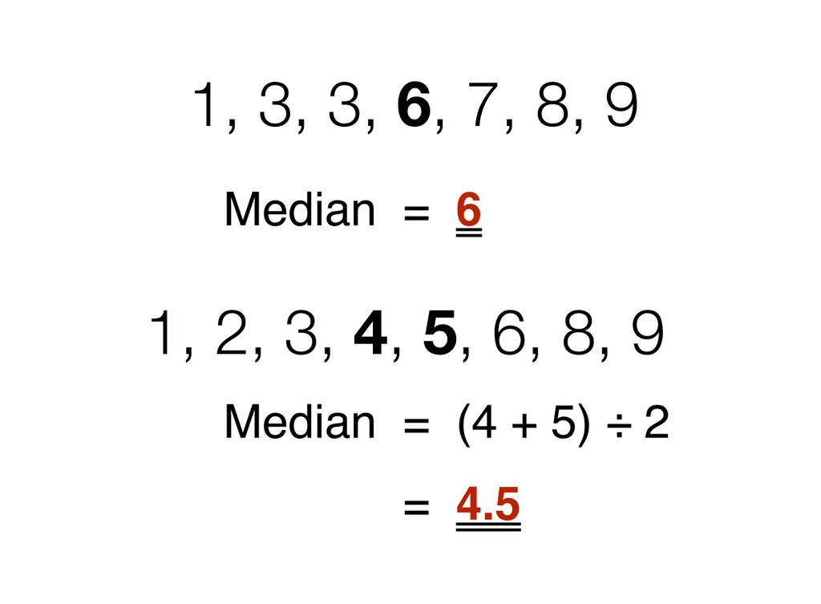

For our puppy weights data set median is:

```r
median(pups)
```

```
## [1] 6
```

```r
mode(pups)
```

```
## [1] "numeric"
```

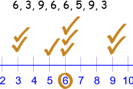

***

#Data Visualization: ###Numerical Univariate DATA: ** 1. Histogram**:A histogram is a diagram consisting of rectangles whose area is proportional to the frequency of a variable and whose width is equal to the class interval. In R histogram can be create like shown below:

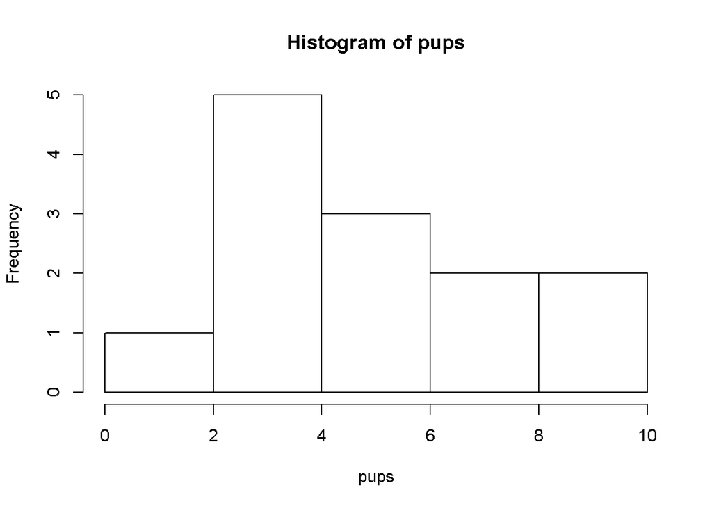

[figure not shown]

```r
hist(pups)
```

**2.Dot Plot**:A dot chart or dot plot is a statistical chart consisting of data points plotted on a fairly simple scale, typically using filled in circles. Dot plot in R can be obtained by dotchart()

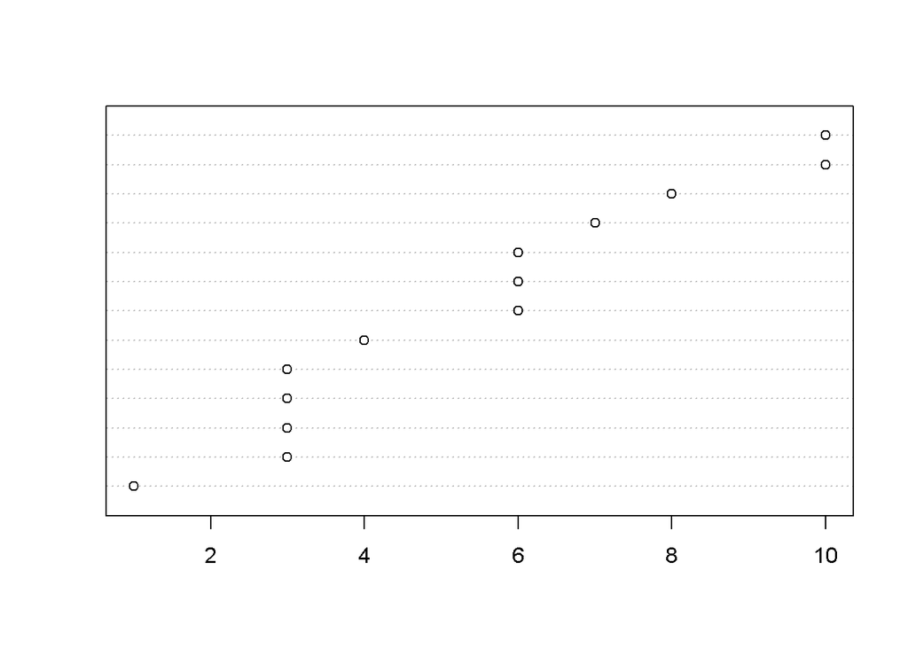

```r
dotchart(pups)
```

**3.Stem and Leaf Plot**:A Stem and Leaf Plot is a special table where each data value is split into a “stem” (the first digit or digits) and a “leaf” (usually the last digit). Like in this example:

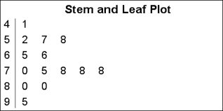

**4.Box and Whisker Plot**:A box and whisker plot is a very convenient and informative way to diplay the info captured in the five number summary. A box and whisker plot shows the centers and spread of the values on a single quantative variable.

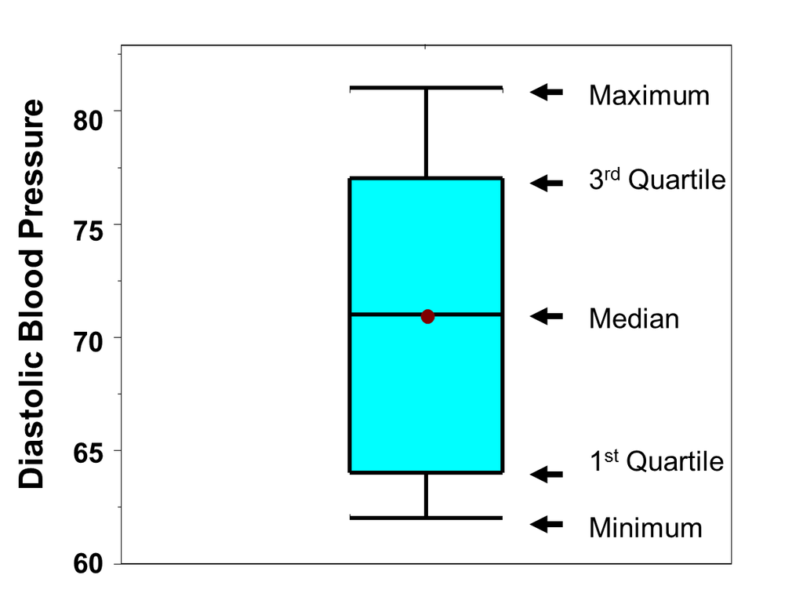

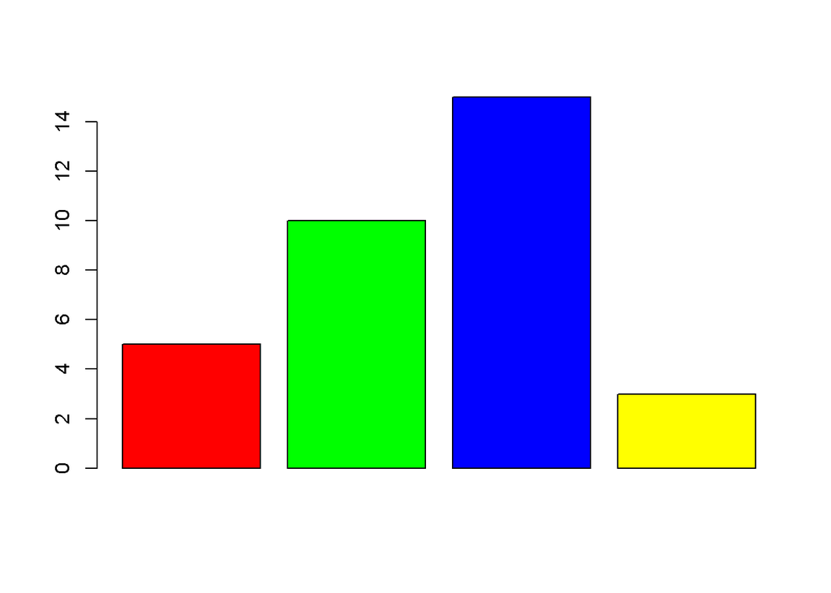

```r
colors=c('red','green','blue','yellow')
freq=c(5,10,15,3)
barplot(freq,col = c('red','green','blue','yellow'))
```

**2.Pie plot**:A pie chart (or a circle chart) is a circular statistical graphic, which is divided into slices to illustrate numerical proportion. In a pie chart, the arc length of each slice (and consequently its central angle and area), is proportional to the quantity it represents.

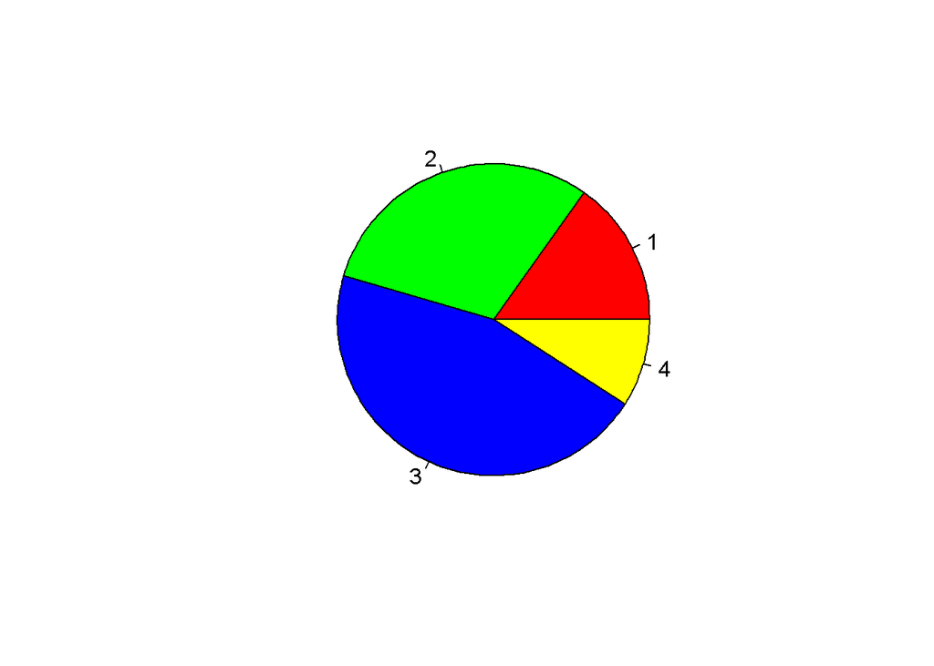

```r
pie(freq,col = c('red','green','blue','yellow'))
```

###Bivariate Data: **1.Scatterp Plot**:A scatter plot (also called a scatterplot) is a type of plot or mathematical diagram using Cartesian coordinates to display values for typically two variables for a set of data

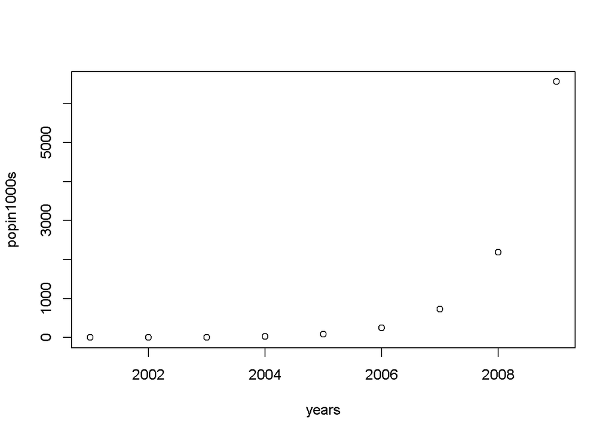

```r
years=(2001:2009)
popin1000s=3^(years-min(years))
plot(years,popin1000s)
```

## Shapes OF Distribuitions:

**1.Symmetric(Bell shaped)**: Unimode. Occurs in normal distributions. - when graphed, a vertical line drawn at the center will Form mirror images, with the leFt halF oF the graph being the mirror image oF the right halF oF the graph.

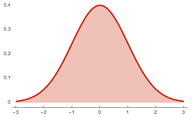

**2.UniForm**: The data is spread equally across the range.

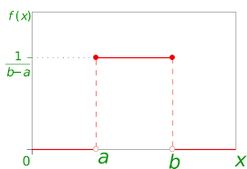

**3.Right Skewed**(positively skewed): Fewer data plots are Found to the right oF the graph (toward the larger numeric values).

**4.LeFt Skewed** (negatively skewed): Fewer data plots are Found to the leFt oF the graph (toward the smaller numeric values).

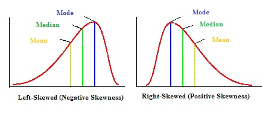

**5.Bimodal**: Usually has two modes.

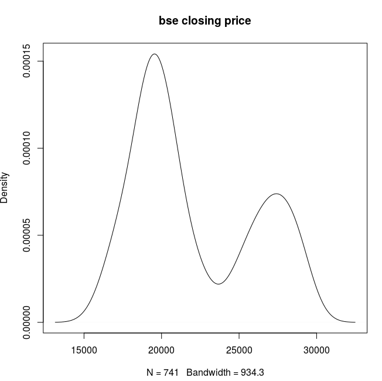

##Creating a Frequency table For A variable:

```r
ptable=table(pups)
ptable
```

```
## pups
##  1  3  4  6  7  8 10
##  1  4  1  3  1  1  2
```

##Plotting Histogram For a Univariate Distribution:

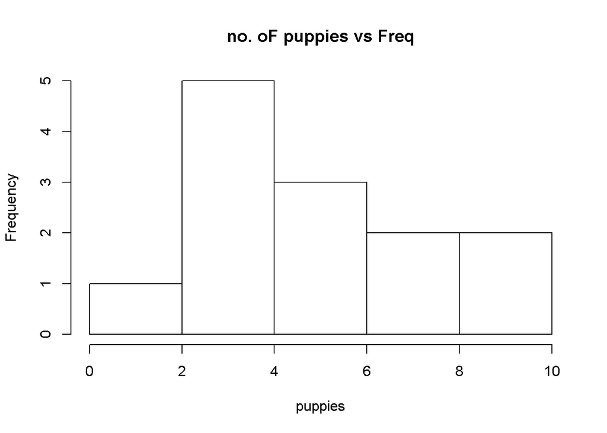

```r
hist(pups,xlab='puppies',ylab='Frequency',main='no. oF puppies vs Freq')
```

##Range and Quartiles: *Range: The range is simply the diFFerence between the smallest value (minimum) and the largest value (maximum) in the data. In our puppies dataset range is:

```r
range(pups)
```

```
## [1]  1 10
```

*Quartile: A quartile divides the data into Four approximately equal groups. The lower quartile,sometimes abbreviated as Q1 , is also know as the 25th percentile.The upper quartile, or Q3, is also know as the 75th percentile. We can get a summary oF our pups data in R using summary() Function which inlcudes quartiles,min,max mean,median,etc..

```r
summary(pups)
```

```
##    Min. 1st Qu.  Median    Mean 3rd Qu.    Max.
##   1.000   3.000   6.000   5.385   7.000  10.000
```

*Interquartile Range: The interquartile range (IQR) is the range oF the data that contains the middle 50% oF cases. $IQR=Q3-Q1$

##five number summary: The five number summary is a numerical description of a data set comprised of the following measures: min,lower quartile,median,upper quartile,max.

```r
fivenum(pups)
```

```
## [1]  1  3  6  7 10
```

##Standard Deviation And Mean: When data is normally Distributed, there are two preferred measures of center and spread. These are arithmetic mean and standard deviation.The **Standard Deviation** of a data set tells us how it is spread out. The larger the standard deviation is,the more spread out data is. A vertical line from inflectionn point to x-axis marks one standard deviation from the mean.Approx 68% of the data is located within one standard deviation of the mean. For out pups data std dev is:

```r
sd(pups)
```

```
## [1] 2.844247
```

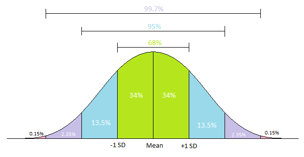

##Variance: **Variance** is also a measure of spread. It is simply the square of Standar Deviation. For our pups data variance is:

```r
var(pups)
```

```
## [1] 8.089744
```

##Emperical Rule: Emperical Rule states that the percentages of data in a normal distribution within 1,2 and 3 standard deviations of the mean are approximately 68%,95% and 99.7%.

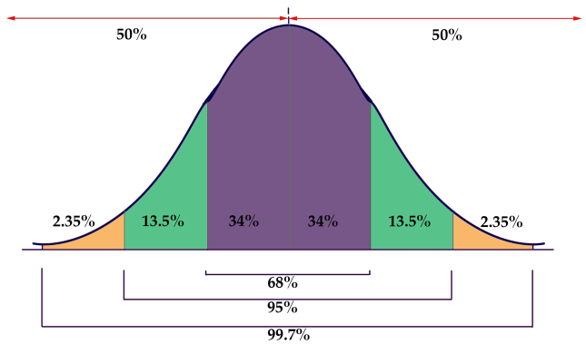

###Z-Score: A **z-score** is a measure of the number of standard deviations a particular data point is away from the mean.
$$z=Deviation/Standard Deviation$$

#Bivariate Data: Bivariate Data is data set with two variables (quantative or categorical). * Correlation **measures the linear relationship between two quantative variables.** Corelation Coefficient**:A correlation coefficient is a numerical measure of some type of correlation, meaning a statistical relationship between two variables.Correlation coefficien time is given by
$$r$$
.

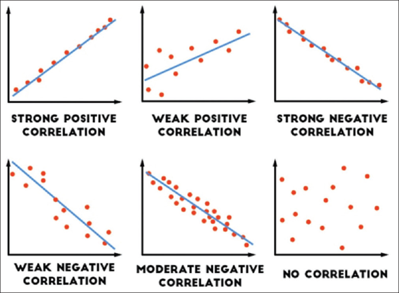

**Outliers**:In statistics, an outlier is an observation point that is distant from other observations. An outlier may be due to variability in the measurement or it may indicate experimental error; the latter are sometimes excluded from the data set.The higher the $r$ value the higher is the correlation between the two variables Outliers can impact data analysis in unwanted ways as shown below:

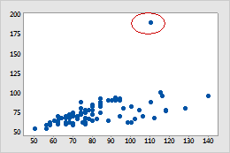

##Choosing between Measures of Center And Spread: **1.Symmetric Distribution**: *Mean* and *Standard Deviation* **2.Skewed Distribution**: *Median* and *IQR*

**NOTE:**: For skewed distribution we use *Median* and *IQR* because median is outlier resistant, where as mean is not.

##Contingency tables: Contingency table shows the distribution of one variable in rows and another in columns, used to study the correlation between the two variables.

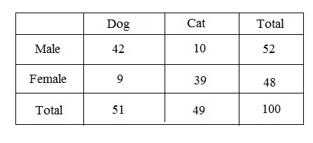

Barplots of contigency tables can help compare the two categorical variables. *** #Regression In statistical modeling, regression analysis is a set of statistical processes for estimating the relationships among variables. It includes many techniques for modeling and analyzing several variables, when the focus is on the relationship between a dependent variable and one or more independent variables.

**1.Linear Regression:** Linear regression is a linear approach to modelling the relationship between a scalar response and one or more explanatory variables. Here, data is modelled to find a line of best fit to the data using [Method of least squares](https://en.wikipedia.org/wiki/Least_squares). The equation is given by
$$y=mx+c$$
where x is independent variable,y is dependent variable,c is y intercept and m is regression coefficient given by:
$$m=r*Sy/Sx$$
where Sy$Sx are standard deviations of respective x and y scores. In R linear model can be fit using lm()

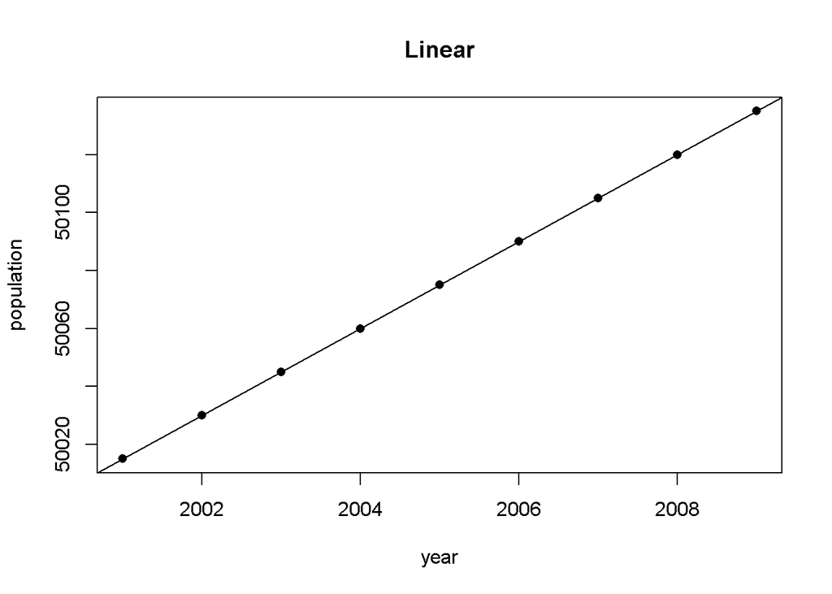

```
## Linear Fit
##  Intercept =  20000
##  Slope =  15
##  R-squared =  1
```

```r
library(SDSFoundations)
year=c(2001:2009)
population=year*15+20000
linFit(year,population)
```

**2.Exponential Regression:** An exponential regression is the process of finding the equation of the exponential function that fits best for a set of data. As a result, we get an equation of the form
$$y=ab^x$$
where y is dependent variable,x is independent variable, a is intercept and b is growth factor. **NOTE**: b (growth factor)is equal to
$$1+rate of change in y$$
. Exponential Regression is usually used in half-life,depreciation,compound interest problems and others.

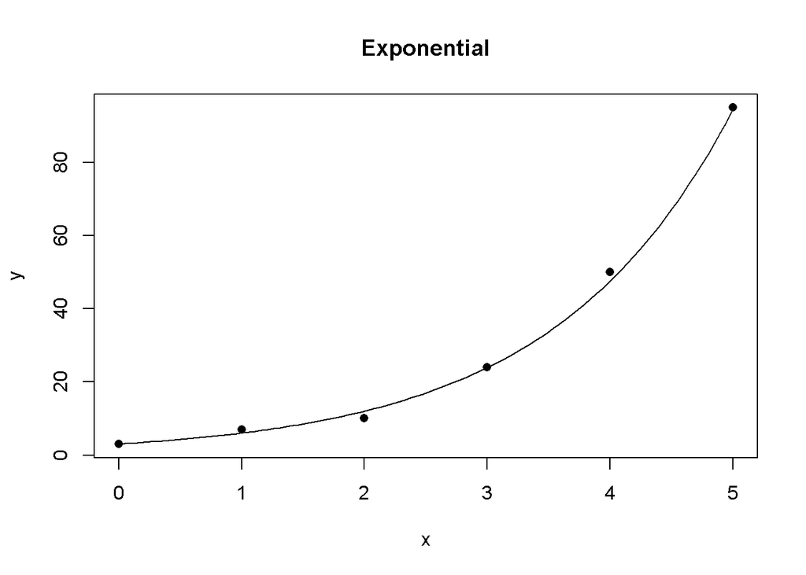

```
## Exponential Fit
##  a =  3.04645
##  b =  1.98803
##  R-squared =  0.99301
```

```r
x=c(0,1,2,3,4,5)
y=c(3,7,10,24,50,95)
expFit(x,y)
```

###Difference b/w Linear and Exponential models: If change in y is constant (Example: y=1,3,5,7) with respect to unit change in x then linear model suits better. if y changes in ratio (Example: y=2,4,8,16)with respect to unit change in x then exponential model is better. *NOTE*: Exponential model can be transformed to linear mdoel by applying log to both sides of exponential equation. i.e
$$y=ab^x$$
is same as
$$log(y)=log(a)+xlog(b)$$

**3.Logistic Regression:** In statistics, the logistic model (or logit model) is a widely used statistical model that, in its basic form, uses a logistic function to model a binary dependent variable. Logistic models are much like exponential models but they have an upper limit due to some factors.
$$f(t)=C/(1+a*b^-t)$$
where c is carrying capacity,a is a constant that helps find f(0),b is growth factor.

**Inflection Point**: The point at which the logistic function starts to slow down. It is
$$C/2$$
where
$$C$$
is carrying capacity.

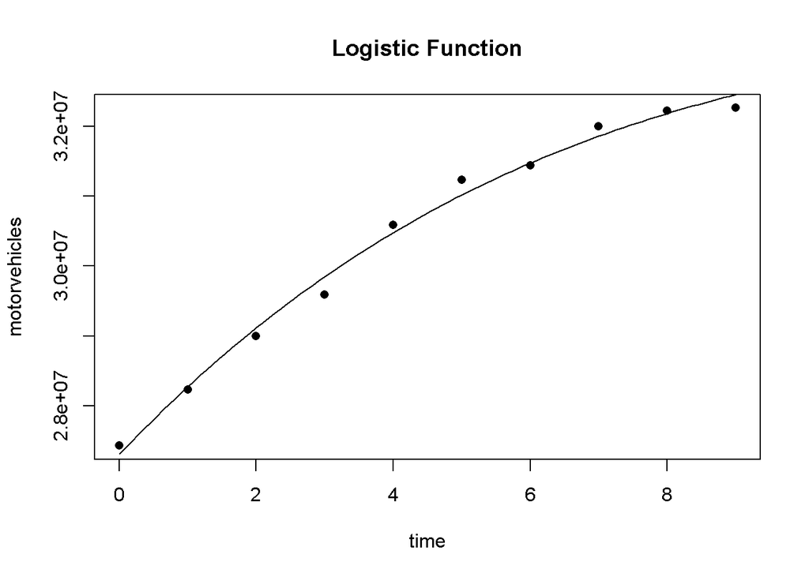

```
## Logistic Fit
##  C =  33759581
##  a =  0.23613
##  b =  1.21695
##  R-squared =  0.99211
```

[figure not shown]

```r
time=0:9
motorvehicles=c(27433000,28236000,28999705,29594461,30590349,31233663,31437297,31998958,32221383,32258677)
logisticFit(time,motorvehicles)
```

#THANK YOU ***